# Lista 1

## Zbiory danych

W projekcie wykorzystano dwa zbiory danych, bo służą one do dwóch różnych zadań:

1. Telco Customer Churn - klasyfikacja - realizacja zadań od 3.0 do 4.5 .
2. Diamonds - regresja - realizacja zadania na 5.0.

### Telco Customer Churn

To zbior opisujacy klientow firmy telekomunikacyjnej i informujący, czy klient zrezygnował z usług (`Churn`).

Najwazniejsze cechy numeryczne to:

- `tenure` - czas korzystania z uslug,
- `MonthlyCharges` - miesięczny koszt uslug,
- `TotalCharges` - laczny koszt klienta,
- `SeniorCitizen` - cecha binarna zapisana liczbowo.

Najwazniejsze cechy kategorialne to:

- `gender`,
- `Contract`,
- `InternetService`,
- `PaymentMethod`,
- `TechSupport`,
- `OnlineSecurity`.

Ten zbior dobrze nadaje sie do klasyfikacji, bo zmienna docelowa ma dwie klasy: klient odszedl albo zostal. W danych widać tez logiczne zależności biznesowe, np. krótki staż, umowa miesięczna i brak wsparcia technicznego zwiększają ryzyko rezygnacji. To dobrze pasuje do recznego budowania prostych reguł `if/else`.

### Diamonds

To zbior opisujący diamenty i ich cene (`price`).

Najwaąniejsze cechy numeryczne to:

- `carat` - masa diamentu,
- `depth`, `table`,
- `x`, `y`, `z` - wymiary kamienia.

Najwaąniejsze cechy kategorialne to:

- `cut` - jakość szlifu,
- `color` - kolor,
- `clarity` - czystość.

Ten zbior nadaje sie do regresji, bo zmienna docelowa jest liczba ciągłą. Najsilniejszą zależność widać dla `carat`, ale pozostałe cechy również maja znaczenie, bo modyfikuja cene w zaleznosci od jakosci i wygladu diamentu. Dlatego da sie tu zbudowac prosty system regresyjny oparty na przedzialach i korektach.

Oba zbiory zawierają jednocześnie cechy liczbowe i kategorialne, wiec dobrze nadaja sie do EDA, kodowania danych oraz budowy prostych reguł decyzyjnych.

```python
import matplotlib.pyplot as plt
import pandas as pd
import seaborn as sns
from constants import (
    CATEGORICAL_COLUMNS,
    CHURN,
    CONTRACT,
    CUSTOMER_ID,
    DATA_FILE,
    DEPENDENTS,
    DEVICE_PROTECTION,
    INTERNET_SERVICE,
    MONTHLY_CHARGES,
    MULTIPLE_LINES,
    NUMERIC_COLUMNS,
    ONLINE_BACKUP,
    ONLINE_SECURITY,
    PAPERLESS_BILLING,
    PARTNER,
    PAYMENT_METHOD,
    PHONE_SERVICE,
    STREAMING_MOVIES,
    STREAMING_TV,
    TECH_SUPPORT,
    TENURE,
)

sns.set_theme(style="whitegrid")
plt.rcParams["figure.figsize"] = (8, 5)

print("Plik z danymi:", DATA_FILE)
```

```
Plik z danymi: resources\WA_Fn-UseC_-Telco-Customer-Churn.csv
```

## Załadowanie pliku

```python
from sklearn.model_selection import train_test_split

data = pd.read_csv(DATA_FILE)

for column in NUMERIC_COLUMNS:
    data[column] = pd.to_numeric(data[column], errors="coerce")
```

# Podział na zbiór testowy i treningowy

Od tego momentu wszystkie decyzje dotyczące konstrukcji reguł, doboru progów i interpretacji cech opieram wyłącznie na zbiorze treningowym, zgodnie z zasadą unikania data leakage.

```python
train_df: pd.DataFrame
test_df: pd.DataFrame

train_df, test_df = train_test_split(data, test_size=0.2, random_state=42, stratify=data[CHURN])
display(train_df.head())
```

|  | customerID | gender | SeniorCitizen | Partner | Dependents | tenure | PhoneService | MultipleLines | InternetService | OnlineSecurity | ... | DeviceProtection | TechSupport | StreamingTV | StreamingMovies | Contract | PaperlessBilling | PaymentMethod | MonthlyCharges | TotalCharges | Churn |
| --- | --- | --- | --- | --- | --- | --- | --- | --- | --- | --- | --- | --- | --- | --- | --- | --- | --- | --- | --- | --- | --- |
| 3738 | 4950-BDEUX | Male | 0 | No | No | 35 | No | No phone service | DSL | No | ... | Yes | No | Yes | Yes | Month-to-month | No | Electronic check | 49.20 | 1701.65 | No |
| 3151 | 7993-NQLJE | Male | 0 | Yes | Yes | 15 | Yes | No | Fiber optic | Yes | ... | No | No | No | No | Month-to-month | No | Mailed check | 75.10 | 1151.55 | No |
| 4860 | 7321-ZNSLA | Male | 0 | Yes | Yes | 13 | No | No phone service | DSL | Yes | ... | No | Yes | No | No | Two year | No | Mailed check | 40.55 | 590.35 | No |
| 3867 | 4922-CVPDX | Female | 0 | Yes | No | 26 | Yes | No | DSL | No | ... | Yes | No | Yes | Yes | Two year | Yes | Credit card (automatic) | 73.50 | 1905.70 | No |
| 3810 | 2903-YYTBW | Male | 0 | Yes | Yes | 1 | Yes | No | DSL | No | ... | No | No | No | No | Month-to-month | No | Electronic check | 44.55 | 44.55 | No |

5 rows × 21 columns

# EDA

wstępna analiza danych

```python
# obliczam tez statystiki ręcznie, bo tak było wymagane w etapie na 3.0
def numeric_statistics(df):
    numeric_data = df[NUMERIC_COLUMNS]

    statistics = pd.DataFrame(
        {
            "srednia": numeric_data.mean(),
            "mediana": numeric_data.median(),
            "min": numeric_data.min(),
            "max": numeric_data.max(),
            "odchylenie_standardowe": numeric_data.std(),
        }
    )

    return pd.DataFrame(statistics.round(2))


print("Pierwsze 5 wierszy:")
display(train_df.head())

print("Informacje o kolumnach:")
train_df.info()

print("Podstawowe statystyki dla cech numerycznych z pandas:")
display(train_df[NUMERIC_COLUMNS].describe().round(2))

print("podstawowe obliczone ręcznie statystkiki dla cech numerycznych")
display(numeric_statistics(train_df))
```

```
Pierwsze 5 wierszy:
```

|  | customerID | gender | SeniorCitizen | Partner | Dependents | tenure | PhoneService | MultipleLines | InternetService | OnlineSecurity | ... | DeviceProtection | TechSupport | StreamingTV | StreamingMovies | Contract | PaperlessBilling | PaymentMethod | MonthlyCharges | TotalCharges | Churn |
| --- | --- | --- | --- | --- | --- | --- | --- | --- | --- | --- | --- | --- | --- | --- | --- | --- | --- | --- | --- | --- | --- |
| 3738 | 4950-BDEUX | Male | 0 | No | No | 35 | No | No phone service | DSL | No | ... | Yes | No | Yes | Yes | Month-to-month | No | Electronic check | 49.20 | 1701.65 | No |
| 3151 | 7993-NQLJE | Male | 0 | Yes | Yes | 15 | Yes | No | Fiber optic | Yes | ... | No | No | No | No | Month-to-month | No | Mailed check | 75.10 | 1151.55 | No |
| 4860 | 7321-ZNSLA | Male | 0 | Yes | Yes | 13 | No | No phone service | DSL | Yes | ... | No | Yes | No | No | Two year | No | Mailed check | 40.55 | 590.35 | No |
| 3867 | 4922-CVPDX | Female | 0 | Yes | No | 26 | Yes | No | DSL | No | ... | Yes | No | Yes | Yes | Two year | Yes | Credit card (automatic) | 73.50 | 1905.70 | No |
| 3810 | 2903-YYTBW | Male | 0 | Yes | Yes | 1 | Yes | No | DSL | No | ... | No | No | No | No | Month-to-month | No | Electronic check | 44.55 | 44.55 | No |

5 rows × 21 columns

```
Informacje o kolumnach:
<class 'pandas.DataFrame'>
Index: 5634 entries, 3738 to 5639
Data columns (total 21 columns):
 #   Column            Non-Null Count  Dtype
---  ------            --------------  -----
 0   customerID        5634 non-null   str
 1   gender            5634 non-null   str
 2   SeniorCitizen     5634 non-null   int64
 3   Partner           5634 non-null   str
 4   Dependents        5634 non-null   str
 5   tenure            5634 non-null   int64
 6   PhoneService      5634 non-null   str
 7   MultipleLines     5634 non-null   str
 8   InternetService   5634 non-null   str
 9   OnlineSecurity    5634 non-null   str
 10  OnlineBackup      5634 non-null   str
 11  DeviceProtection  5634 non-null   str
 12  TechSupport       5634 non-null   str
 13  StreamingTV       5634 non-null   str
 14  StreamingMovies   5634 non-null   str
 15  Contract          5634 non-null   str
 16  PaperlessBilling  5634 non-null   str
 17  PaymentMethod     5634 non-null   str
 18  MonthlyCharges    5634 non-null   float64
 19  TotalCharges      5626 non-null   float64
 20  Churn             5634 non-null   str
dtypes: float64(2), int64(2), str(17)
memory usage: 968.3 KB
Podstawowe statystyki dla cech numerycznych z pandas:
```

|  | tenure | MonthlyCharges | TotalCharges | SeniorCitizen |
| --- | --- | --- | --- | --- |
| count | 5634.00 | 5634.00 | 5626.00 | 5634.00 |
| mean | 32.49 | 64.93 | 2302.60 | 0.16 |
| std | 24.57 | 30.14 | 2279.17 | 0.37 |
| min | 0.00 | 18.40 | 18.85 | 0.00 |
| 25% | 9.00 | 35.66 | 407.28 | 0.00 |
| 50% | 29.00 | 70.50 | 1398.12 | 0.00 |
| 75% | 55.00 | 90.00 | 3838.61 | 0.00 |
| max | 72.00 | 118.75 | 8684.80 | 1.00 |

```
podstawowe obliczone ręcznie statystkiki dla cech numerycznych
```

|  | srednia | mediana | min | max | odchylenie_standardowe |
| --- | --- | --- | --- | --- | --- |
| tenure | 32.49 | 29.00 | 0.00 | 72.00 | 24.57 |
| MonthlyCharges | 64.93 | 70.50 | 18.40 | 118.75 | 30.14 |
| TotalCharges | 2302.60 | 1398.12 | 18.85 | 8684.80 | 2279.17 |
| SeniorCitizen | 0.16 | 0.00 | 0.00 | 1.00 | 0.37 |

## Wybrane ciekawe zależności i dane

```python
def tenure_histogram(df):
    plt.figure(figsize=(8, 5))
    sns.histplot(data=df, x=TENURE, bins=20, color="skyblue", edgecolor="black")
    plt.title("Histogram: czas trwania umowy")
    plt.xlabel("czas trwania umowy")
    plt.ylabel("Liczba klientow")
    plt.tight_layout()
    plt.show()


def tenure_churn_boxplot(df):
    plt.figure(figsize=(8, 5))
    sns.boxplot(data=df, x=CHURN, y=TENURE)
    plt.title("Boxplot: czas trwania umowy wzgledem rezygnacji")
    plt.xlabel("Rezygnacja")
    plt.ylabel("czas trwania umowy")
    plt.tight_layout()
    plt.show()


def monthly_charges_histogram(df):
    plt.figure(figsize=(8, 5))
    sns.histplot(data=df, x=MONTHLY_CHARGES, bins=20, color="orange", edgecolor="black")
    plt.title("Histogram: miesieczna oplata")
    plt.xlabel("miesieczna oplata")
    plt.ylabel("Liczba klientow")
    plt.tight_layout()
    plt.show()


def monthly_charges_churn_boxplot(df) :
    plt.figure(figsize=(8, 5))
    sns.boxplot(data=df, x=CHURN, y=MONTHLY_CHARGES)
    plt.title("Boxplot: miesieczna oplata wzgledem rezygnacji")
    plt.xlabel("Rezygnacja")
    plt.ylabel("miesieczna oplata")
    plt.tight_layout()
    plt.show()


def tenure_monthly_charges_scatter(df):
    plt.figure(figsize=(8, 5))
    sns.scatterplot(data=df, x=TENURE, y=MONTHLY_CHARGES, hue=CHURN, alpha=0.7)
    plt.title("Wykres rozrzutu: czas trwania umowy i miesieczna oplata")
    plt.xlabel("czas trwania umowy")
    plt.ylabel("miesieczna oplata")
    plt.legend(title="Rezygnacja")
    plt.tight_layout()
    plt.show()
```

### Uzasadnienie wyboru zmiennych i zależności

- `tenure` - pokazuje, jak dlugo klient korzysta z usług. Nowi klienci zwykle częściej rezygnują.
- `MonthlyCharges` - pokazuje miesięczny koszt usług. Wysoka oplata moze zwiekszac ryzyko odejścia.
- `tenure` vs `Churn` - pozwala sprawdzić, czy klienci odchodzący mają krótszy czas korzystania z usług.
- `MonthlyCharges` vs `Churn` - pokazuje, czy osoby odchodzace płacą wiecej niz pozostali klienci.
- `tenure` vs `MonthlyCharges` - pozwala zobaczyc zależność miedzy długością umowy i wysokością opłat.

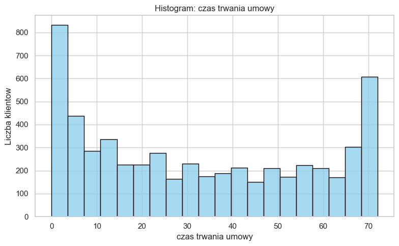

```python
tenure_histogram(train_df)
```

**opis:** Rozkład zmiennej czas trwania umowy (tenure) wskazuje na dużą liczbę klientów o bardzo krótkim stażu, co może oznaczać wysoki napływ nowych użytkowników. Jednocześnie obserwujemy wyraźne skupienie klientów o bardzo długim czasie korzystania z usług (około 70 miesięcy), co świadczy o istnieniu lojalnej grupy klientów. Rozkład ma charakter dwumodalny, co sugeruje, że klienci dzielą się na nowe oraz długoletnie grupy, a wartości pośrednie występują rzadzie

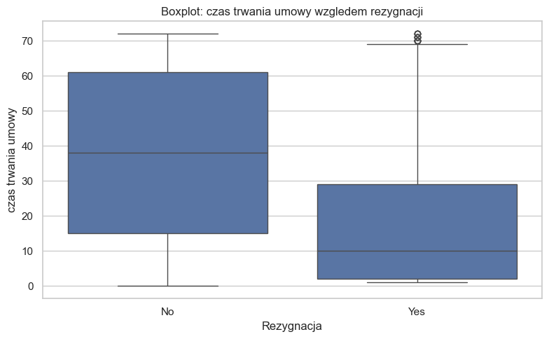

```python
tenure_churn_boxplot(train_df)
```

**opis:** Wykres pudełkowy pokazuje wyraźną różnicę w czasie trwania umowy pomiędzy klientami, którzy zrezygnowali z usług, a tymi, którzy pozostali. Klienci, którzy odeszli (Churn = Yes), mają zdecydowanie krótszy staż – ich mediana wynosi około 10 miesięcy. Z kolei klienci pozostający w firmie charakteryzują się znacznie dłuższym okresem korzystania z usług (mediana około 38 miesięcy). Sugeruje to, że ryzyko rezygnacji jest najwyższe w początkowym okresie relacji z klientem.

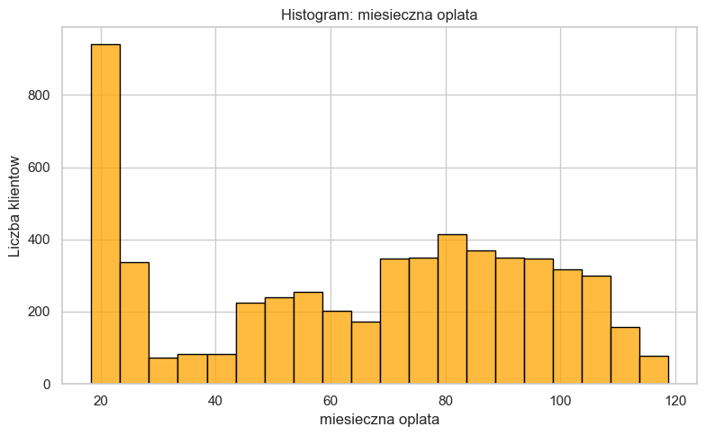

```python
monthly_charges_histogram(train_df)
```

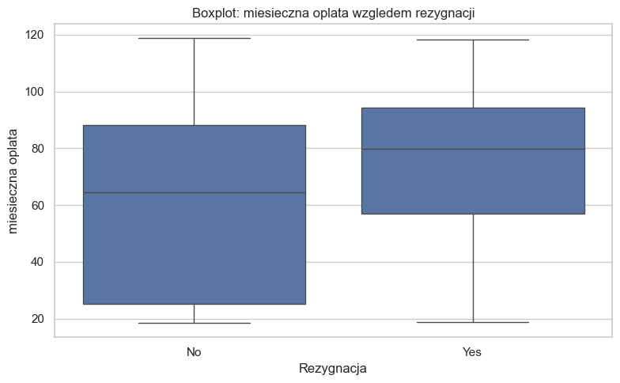

```python
monthly_charges_churn_boxplot(train_df)
```

**opis:** Klienci, którzy rezygnują z usług, charakteryzują się wyższymi miesięcznymi opłatami niż klienci pozostający w firmie. Mediana opłaty dla grupy churn = Yes jest wyraźnie wyższa, co sugeruje, że wyższy koszt usług może zwiększać prawdopodobieństwo rezygnacji.(mediana ok. 80 zł vs 65 zł).

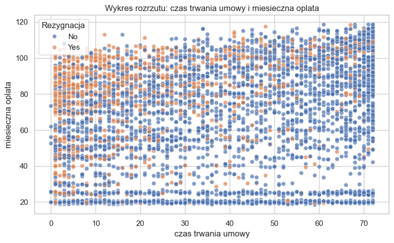

```python
tenure_monthly_charges_scatter(train_df)
```

**opis:** Największa gęstość rezygnacji (punkty pomarańczowe) występuje w obszarze krótkiego stażu i wysokich opłat (lewy górny róg wykresu).

### końcowy wniosek z wykresów

Z Wykresów wynika, że najbardziej obiecujace cechy to `tenure` (czas trwania umowy) i `MonthlyCharges` (opłaty miesięczne), bezposrednio pokazuja, jak dlugo klient zostaje i ile placi. Cechy te mają największy wpływ na ryzyko rezygnacji klientów

## EDA na danych kategorialnych

```python
categorial_df = train_df[CATEGORICAL_COLUMNS]


def get_categorial_stats(df):
    basic_stats = df.describe().round(2)
    top_prop = pd.DataFrame((basic_stats.loc['freq'] / basic_stats.loc['count'] * 100).round(2)).T
    top_prop.index = ['top_share_%']
    full_eda = pd.concat([basic_stats, top_prop], axis=0)
    return full_eda


categorial_df.info()
display(get_categorial_stats(categorial_df))
```

```
<class 'pandas.DataFrame'>
Index: 5634 entries, 3738 to 5639
Data columns (total 15 columns):
 #   Column            Non-Null Count  Dtype
---  ------            --------------  -----
 0   gender            5634 non-null   str
 1   Partner           5634 non-null   str
 2   Dependents        5634 non-null   str
 3   PhoneService      5634 non-null   str
 4   MultipleLines     5634 non-null   str
 5   InternetService   5634 non-null   str
 6   OnlineSecurity    5634 non-null   str
 7   OnlineBackup      5634 non-null   str
 8   DeviceProtection  5634 non-null   str
 9   TechSupport       5634 non-null   str
 10  StreamingTV       5634 non-null   str
 11  StreamingMovies   5634 non-null   str
 12  Contract          5634 non-null   str
 13  PaperlessBilling  5634 non-null   str
 14  PaymentMethod     5634 non-null   str
dtypes: str(15)
memory usage: 704.2 KB
```

|  | gender | Partner | Dependents | PhoneService | MultipleLines | InternetService | OnlineSecurity | OnlineBackup | DeviceProtection | TechSupport | StreamingTV | StreamingMovies | Contract | PaperlessBilling | PaymentMethod |
| --- | --- | --- | --- | --- | --- | --- | --- | --- | --- | --- | --- | --- | --- | --- | --- |
| count | 5634 | 5634 | 5634 | 5634 | 5634 | 5634 | 5634 | 5634 | 5634 | 5634 | 5634 | 5634 | 5634 | 5634 | 5634 |
| unique | 2 | 2 | 2 | 2 | 3 | 3 | 3 | 3 | 3 | 3 | 3 | 3 | 3 | 2 | 4 |
| top | Male | No | No | Yes | No | Fiber optic | No | No | No | No | No | No | Month-to-month | Yes | Electronic check |
| freq | 2833 | 2905 | 3955 | 5075 | 2685 | 2483 | 2797 | 2442 | 2472 | 2771 | 2226 | 2217 | 3102 | 3331 | 1891 |
| top_share_% | 50.28 | 51.56 | 70.2 | 90.08 | 47.66 | 44.07 | 49.65 | 43.34 | 43.88 | 49.18 | 39.51 | 39.35 | 55.06 | 59.12 | 33.56 |

```python
def plot_encoded_categorical_feature(
    df,
    column,
    title,
    tick_labels,
):
    plt.figure(figsize=(9, 5))

    data = (
        df.groupby(column)[CHURN]
        .value_counts(normalize=True)
        .rename("percentage")
        .reset_index()
    )

    data = data[data[CHURN] == "Yes"]

    sns.barplot(data=data, x=column, y="percentage")

    plt.title(title)
    plt.xlabel(column)
    plt.ylabel("Udział churn")
    plt.ylim(0, 1)

    plt.tight_layout()
    plt.show()


selected_categorical_features = [
    CONTRACT,
    INTERNET_SERVICE,
    PAYMENT_METHOD,
    TECH_SUPPORT,
    ONLINE_SECURITY,
]
```

### Krotkie uzasadnienie doboru cech

- `Contract` - umowa miesieczna zwykle oznacza większe ryzyko rezygnacji i daje prostą regule decyzyjna.
- `InternetService` - rodzaj internetu może wskazywać na róznice w cenie i jakości uslugi.
- `PaymentMethod` - sposób platności często dzieli bardziej stabilnych i mniej stabilnych klientow.
- `TechSupport` - brak wsparcia technicznego moze zwiększac frustracje klientów i wpływać na ich rezygnacje.
- `OnlineSecurity` - dodatkowe zabezpieczenia mogą zmniejszać ryzyko odejścia klienta.

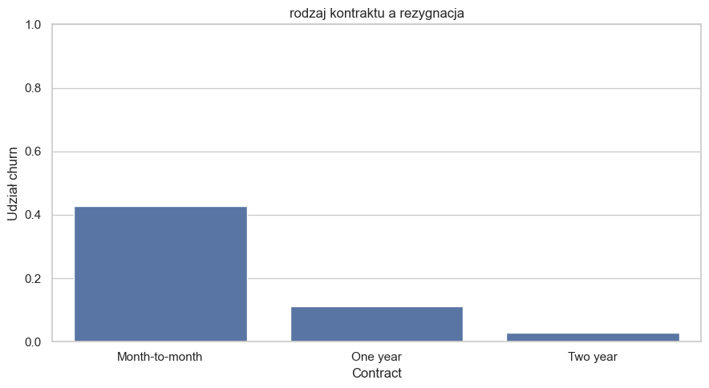

```python
plot_encoded_categorical_feature(
	train_df,
	CONTRACT,
	"rodzaj kontraktu a rezygnacja",
	["Month-to-month", "One year", "Two year"],
)
```

**opis:** Typ umowy (Contract) wykazuje silną zależność z rezygnacją. Najwyższy wskaźnik Churn dotyczy umów Month-to-month, co potwierdza, że brak długoterminowego zobowiązania jest kluczowym predyktorem odejścia

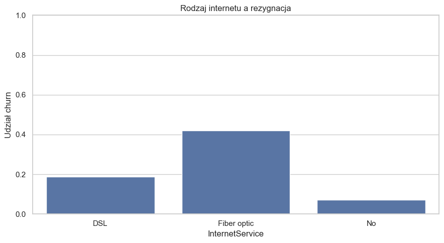

```python
plot_encoded_categorical_feature(
    train_df,
    INTERNET_SERVICE,
    "Rodzaj internetu a rezygnacja",
    ["No", "DSL", "Fiber optic"],
)
```

**opis:** Najwięcej rezygnacji obserwujemy wśród klientów korzystających ze światlowodu

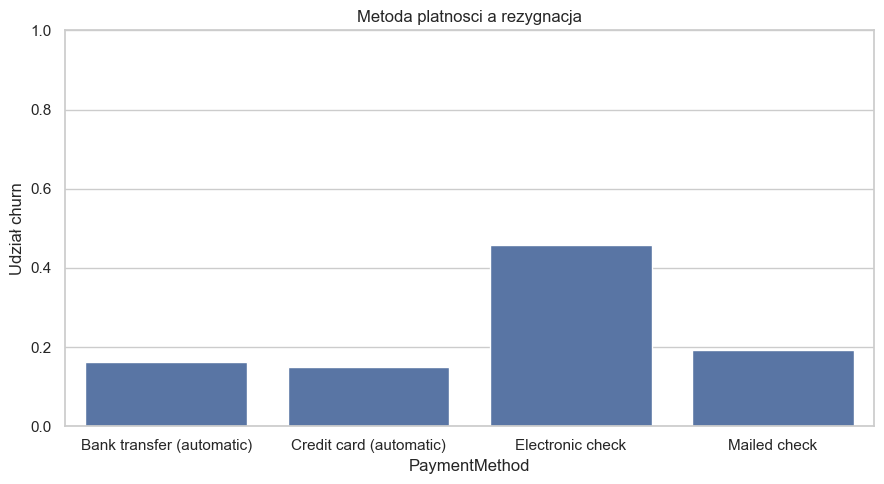

```python
plot_encoded_categorical_feature(
    train_df,
    PAYMENT_METHOD,
    "Metoda platnosci a rezygnacja",
    ["Electronic check", "Mailed check", "Bank transfer (automatic)", "Credit card (automatic)"],
)
```

**opis:** Najwyższy udział rezygnacji obserwujemy wśród klientów korzystających z metody Electronic check. Pozostałe metody płatności mają wyraźnie niższy poziom churn, co sugeruje, że sposób płatności dobrze różnicuje bardziej i mniej stabilnych klientów.

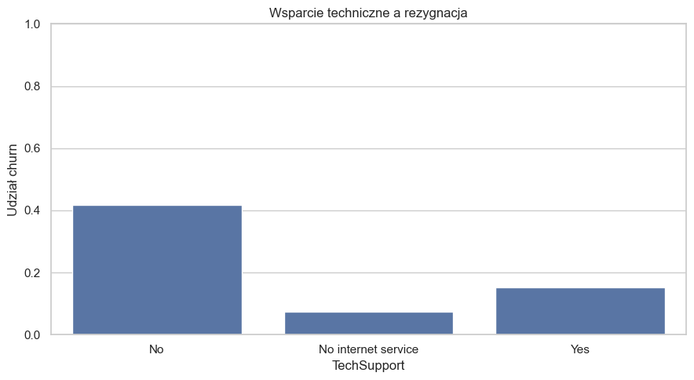

```python
plot_encoded_categorical_feature(train_df,
                                 TECH_SUPPORT,
                                 "Wsparcie techniczne a rezygnacja",
                                 ["No", "Yes", "Brak internetu"])
```

**opis:** Osoby, które nie korzystają z wsparcia technicznego (No), rezygnują masowo. Z kolei klienci mający zapewniony TechSupport (Yes) odchodzą rzadko.

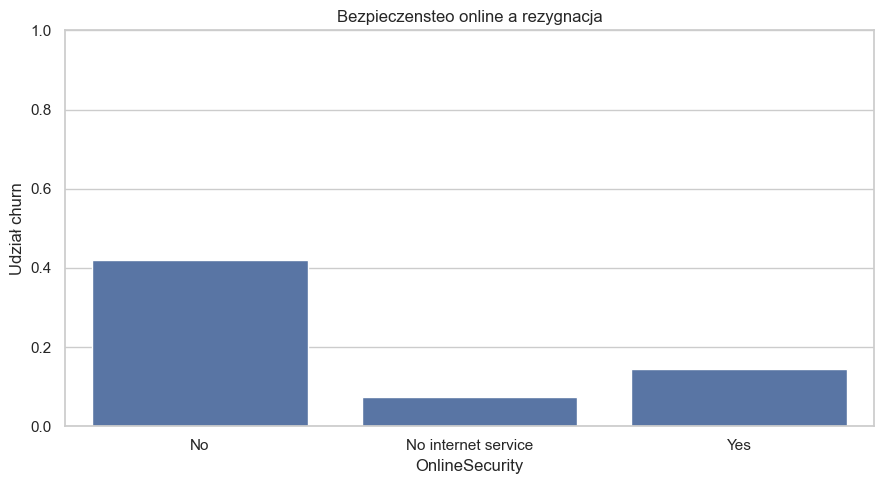

```python
plot_encoded_categorical_feature(train_df,
                                 ONLINE_SECURITY,
                                 "Bezpieczensteo online a rezygnacja",
                                 ["No", "Yes", "Brak internetu"])
```

**opis:** Wykres jest niemal identyczny jak w przypadku TechSupport. Brak usługi OnlineSecurity drastycznie zwiększa prawdopodobieństwo rezygnacji.

## Kodowanie cech tekstowych na liczby

W tej czesci zamieniam wszystkie kolumny tekstowe z `train_df` na liczby. Dla prostych cech binarnych używam prostego ręcznego mapowania No=0, Yes=1, inna_opca = 2. Dla większej ilości możliwych wyników Uzywam `pd.factorize`, bo to najprostszy sposob, zeby zakodowac kazda wartość będącą stringiem na liczbe.

```python
def apply_mapping(df, columns, mapping):
    for column in columns:
        if column in df.columns:
            df[column] = df[column].map(mapping)
    return df


def factorize_columns(
    train_frame,
    test_frame,
    columns,
    excluded_columns,
):
    mappings: dict[str, dict[str, int]] = {}
    useful_columns = [column for column in columns if column not in excluded_columns]

    for column in useful_columns:
        train_frame[column], unique_values = pd.factorize(train_frame[column])
        mappings[column] = {value: code for code, value in enumerate(unique_values)}

    for column, mapping in mappings.items():
        if column in test_frame.columns:
            test_frame[column] = test_frame[column].map(mapping)

    return train_frame, test_frame, mappings


encoded_train_df = train_df.copy()
encoded_test_df = test_df.copy()

string_columns = encoded_train_df.select_dtypes(include=["object", "string"]).columns.tolist()
string_columns = [column for column in string_columns if column != CUSTOMER_ID]

binary_cols = [PARTNER, DEPENDENTS, PAPERLESS_BILLING, PHONE_SERVICE, CHURN]
binary_cols_ns = [ONLINE_SECURITY, ONLINE_BACKUP, DEVICE_PROTECTION, TECH_SUPPORT, STREAMING_TV, STREAMING_MOVIES]
binary_cols_ps = [MULTIPLE_LINES]
factorized_cols = string_columns

binary_mapping = {"No": 0, "Yes": 1}
binary_mapping_ns = {"No": 0, "Yes": 1, "No internet service": 2}
binary_mapping_ps = {"No": 0, "Yes": 1, "No phone service": 2}

encoded_train_df = apply_mapping(encoded_train_df, binary_cols, binary_mapping)
encoded_test_df = apply_mapping(encoded_test_df, binary_cols, binary_mapping)

encoded_train_df = apply_mapping(encoded_train_df, binary_cols_ns, binary_mapping_ns)
encoded_test_df = apply_mapping(encoded_test_df, binary_cols_ns, binary_mapping_ns)

encoded_train_df = apply_mapping(encoded_train_df, binary_cols_ps, binary_mapping_ps)
encoded_test_df = apply_mapping(encoded_test_df, binary_cols_ps, binary_mapping_ps)

encoded_train_df, encoded_test_df, string_mappings = factorize_columns(
    encoded_train_df,
    encoded_test_df,
    factorized_cols,
    binary_cols + binary_cols_ns + binary_cols_ps,
)

print("Kolumny tekstowe zakodowane na liczby:")
print(string_columns)

display(encoded_train_df.head())
display(encoded_test_df.head())
```

```
Kolumny tekstowe zakodowane na liczby:
['gender', 'Partner', 'Dependents', 'PhoneService', 'MultipleLines', 'InternetService', 'OnlineSecurity', 'OnlineBackup', 'DeviceProtection', 'TechSupport', 'StreamingTV', 'StreamingMovies', 'Contract', 'PaperlessBilling', 'PaymentMethod', 'Churn']
```

|  | customerID | gender | SeniorCitizen | Partner | Dependents | tenure | PhoneService | MultipleLines | InternetService | OnlineSecurity | ... | DeviceProtection | TechSupport | StreamingTV | StreamingMovies | Contract | PaperlessBilling | PaymentMethod | MonthlyCharges | TotalCharges | Churn |
| --- | --- | --- | --- | --- | --- | --- | --- | --- | --- | --- | --- | --- | --- | --- | --- | --- | --- | --- | --- | --- | --- |
| 3738 | 4950-BDEUX | 0 | 0 | 0 | 0 | 35 | 0 | 2 | 0 | 0 | ... | 1 | 0 | 1 | 1 | 0 | 0 | 0 | 49.20 | 1701.65 | 0 |
| 3151 | 7993-NQLJE | 0 | 0 | 1 | 1 | 15 | 1 | 0 | 1 | 1 | ... | 0 | 0 | 0 | 0 | 0 | 0 | 1 | 75.10 | 1151.55 | 0 |
| 4860 | 7321-ZNSLA | 0 | 0 | 1 | 1 | 13 | 0 | 2 | 0 | 1 | ... | 0 | 1 | 0 | 0 | 1 | 0 | 1 | 40.55 | 590.35 | 0 |
| 3867 | 4922-CVPDX | 1 | 0 | 1 | 0 | 26 | 1 | 0 | 0 | 0 | ... | 1 | 0 | 1 | 1 | 1 | 1 | 2 | 73.50 | 1905.70 | 0 |
| 3810 | 2903-YYTBW | 0 | 0 | 1 | 1 | 1 | 1 | 0 | 0 | 0 | ... | 0 | 0 | 0 | 0 | 0 | 0 | 0 | 44.55 | 44.55 | 0 |

5 rows × 21 columns

|  | customerID | gender | SeniorCitizen | Partner | Dependents | tenure | PhoneService | MultipleLines | InternetService | OnlineSecurity | ... | DeviceProtection | TechSupport | StreamingTV | StreamingMovies | Contract | PaperlessBilling | PaymentMethod | MonthlyCharges | TotalCharges | Churn |
| --- | --- | --- | --- | --- | --- | --- | --- | --- | --- | --- | --- | --- | --- | --- | --- | --- | --- | --- | --- | --- | --- |
| 437 | 4376-KFVRS | 0 | 0 | 1 | 1 | 72 | 1 | 1 | 1 | 1 | ... | 1 | 1 | 1 | 1 | 1 | 1 | 2 | 114.05 | 8468.20 | 0 |
| 2280 | 2754-SDJRD | 1 | 1 | 0 | 0 | 8 | 1 | 1 | 1 | 0 | ... | 0 | 1 | 1 | 1 | 0 | 1 | 2 | 100.15 | 908.55 | 0 |
| 2235 | 9917-KWRBE | 1 | 0 | 1 | 1 | 41 | 1 | 1 | 0 | 1 | ... | 1 | 0 | 1 | 0 | 2 | 1 | 2 | 78.35 | 3211.20 | 0 |
| 4460 | 0365-GXEZS | 0 | 0 | 1 | 0 | 18 | 1 | 0 | 1 | 0 | ... | 1 | 1 | 0 | 0 | 0 | 0 | 0 | 78.20 | 1468.75 | 0 |
| 3761 | 9385-NXKDA | 1 | 0 | 1 | 0 | 72 | 1 | 1 | 0 | 1 | ... | 1 | 0 | 1 | 1 | 1 | 1 | 2 | 82.65 | 5919.35 | 0 |

5 rows × 21 columns

```python
# wyswietlanie kodowania
mappings_wide = {}

for col, mapping in string_mappings.items():
    formatted_list = [f"{val} = {code}" for val, code in mapping.items()]
    mappings_wide[col] = formatted_list

max_len = max(len(v) for v in mappings_wide.values())
for col in mappings_wide:
    while len(mappings_wide[col]) < max_len:
        mappings_wide[col].append("")

mapping_table = pd.DataFrame(mappings_wide)

# Wyświetlamy
display(mapping_table.head())
display(encoded_train_df.head())
```

|  | gender | InternetService | Contract | PaymentMethod |
| --- | --- | --- | --- | --- |
| 0 | Male = 0 | DSL = 0 | Month-to-month = 0 | Electronic check = 0 |
| 1 | Female = 1 | Fiber optic = 1 | Two year = 1 | Mailed check = 1 |
| 2 |  | No = 2 | One year = 2 | Credit card (automatic) = 2 |
| 3 |  |  |  | Bank transfer (automatic) = 3 |

|  | customerID | gender | SeniorCitizen | Partner | Dependents | tenure | PhoneService | MultipleLines | InternetService | OnlineSecurity | ... | DeviceProtection | TechSupport | StreamingTV | StreamingMovies | Contract | PaperlessBilling | PaymentMethod | MonthlyCharges | TotalCharges | Churn |
| --- | --- | --- | --- | --- | --- | --- | --- | --- | --- | --- | --- | --- | --- | --- | --- | --- | --- | --- | --- | --- | --- |
| 3738 | 4950-BDEUX | 0 | 0 | 0 | 0 | 35 | 0 | 2 | 0 | 0 | ... | 1 | 0 | 1 | 1 | 0 | 0 | 0 | 49.20 | 1701.65 | 0 |
| 3151 | 7993-NQLJE | 0 | 0 | 1 | 1 | 15 | 1 | 0 | 1 | 1 | ... | 0 | 0 | 0 | 0 | 0 | 0 | 1 | 75.10 | 1151.55 | 0 |
| 4860 | 7321-ZNSLA | 0 | 0 | 1 | 1 | 13 | 0 | 2 | 0 | 1 | ... | 0 | 1 | 0 | 0 | 1 | 0 | 1 | 40.55 | 590.35 | 0 |
| 3867 | 4922-CVPDX | 1 | 0 | 1 | 0 | 26 | 1 | 0 | 0 | 0 | ... | 1 | 0 | 1 | 1 | 1 | 1 | 2 | 73.50 | 1905.70 | 0 |
| 3810 | 2903-YYTBW | 0 | 0 | 1 | 1 | 1 | 1 | 0 | 0 | 0 | ... | 0 | 0 | 0 | 0 | 0 | 0 | 0 | 44.55 | 44.55 | 0 |

5 rows × 21 columns

## Pierwsza prosta reguła decyzyjna

Na podstawie wykresów o zmiennej `tenure` (czas trwania umowy) wybieram te cechę, bo bardzo wyraźnie rozdziela klientow zostajacych i rezygnujacych. Reguła bedzie bardzo prosta: jeżeli klient ma krótki staż, przewiduj rezygnacje, w przeciwnym razie przewiduj brak rezygnacji. Do wyznaczenia wyznaczenia optymalnego progu decyzyjnego używam prostego algorytmu typu GridSearch, co pozwoliło na obiektywny dobór parametru nie kierując się subiektywnym spojrzeniem na wykresy

```python
from sklearn.metrics import accuracy_score

y_train = encoded_train_df[CHURN]
y_test = encoded_test_df[CHURN]

possible_thresholds = range(1, 73)
best_threshold = 1
best_train_accuracy = 0.0

for threshold in possible_thresholds:
    train_predictions = (encoded_train_df[TENURE] < threshold).astype(int)
    current_accuracy = accuracy_score(y_train, train_predictions)

    if current_accuracy > best_train_accuracy:
        best_train_accuracy = current_accuracy
        best_threshold = threshold

print(f"Najlepszy prog dla tenure: {best_threshold}")
print(f"Accuracy na zbiorze treningowym: {best_train_accuracy:.4f}")


def predict(tenure: int, *args, **kwargs) -> int:
    if tenure < best_threshold:
        return 1
    return 0
```

```
Najlepszy prog dla tenure: 2
Accuracy na zbiorze treningowym: 0.7533
```

```python
test_predictions = encoded_test_df[TENURE].apply(lambda value: predict(value))
test_accuracy = accuracy_score(y_test, test_predictions)

print(f"Accuracy na zbiorze testowym: {test_accuracy:.4f}")
display(pd.DataFrame({"prawdziwa_wartosc": y_test, "predykcja": test_predictions}).head(10))
```

```
Accuracy na zbiorze testowym: 0.7566
```

|  | prawdziwa_wartosc | predykcja |
| --- | --- | --- |
| 437 | 0 | 0 |
| 2280 | 0 | 0 |
| 2235 | 0 | 0 |
| 4460 | 0 | 0 |
| 3761 | 0 | 0 |
| 5748 | 0 | 0 |
| 3568 | 0 | 0 |
| 2976 | 0 | 0 |
| 5928 | 0 | 0 |
| 1639 | 1 | 0 |

### Wniosek

Uzyskany wynik Accuracy na poziomie 75,66% pokazuje, że nawet pojedyncza cecha tenure niesie istotną informację predykcyjną, choć sam wynik należy interpretować ostrożnie, ponieważ model jest bardzo uproszczony i opiera się tylko na jednym progu decyzyjnym.

Warto zauważyć, że próg 2 miesięcy został wybrany nie dlatego, że najlepiej opisuje cały rozkład odejść, lecz dlatego, że maksymalizuje Accuracy na zbiorze treningowym. Jest to próg bardzo konserwatywny — wychwytuje głównie najbardziej oczywiste przypadki szybkiej rezygnacji. Oznacza to, że metryka Accuracy może preferować węższy próg niż ten, który intuicyjnie wynika z boxplota.

# Złożony system decyzyjny

W rozbudowanej wersji systemu zidentyfikowałem 5 kluczowych scenariuszy ryzyka, opartych na statystycznych progach (mediana i 3 kwantyl): Rezygnacja w przypadku gdy:

- Nowy klient jest na krótkiej umowie.
- Nowy klient z wysokimi kosztami
- umowa miesięczna i brak wsparcia
- długi staż klienta ale przepłacający

Brak rezygnacji gdy:

- Klienci są na kontraktach terminowych, którzy korzystają z usług dodatkowych

```python
short_tenure_threshold = best_threshold
monthly_threshold = float(encoded_train_df[MONTHLY_CHARGES].median())
high_charge_threshold = float(encoded_train_df[MONTHLY_CHARGES].quantile(0.75))


def predict_complex(tenure, monthly_charges, contract, tech_support, online_security, *args, **kwargs) -> int:
    if tenure < short_tenure_threshold and contract == 0:
        return 1

    if tenure < short_tenure_threshold and monthly_charges >= monthly_threshold:
        return 1

    if contract == 0 and tech_support == 0 and online_security == 0:
        return 1

    if tenure >= short_tenure_threshold and contract == 0 and monthly_charges >= high_charge_threshold:
        return 1

    if contract != 0 and (tech_support == 1 or online_security == 1):
        return 0

    return 0
```

```python
complex_test_predictions = encoded_test_df.apply(
    lambda row: predict_complex(
        row[TENURE],
        row[MONTHLY_CHARGES],
        row[CONTRACT],
        row[TECH_SUPPORT],
        row[ONLINE_SECURITY],
    ),
    axis=1,
)

complex_test_accuracy = accuracy_score(y_test, complex_test_predictions)

print(f"Accuracy prostego systemu: {test_accuracy:.4f}")
print(f"Accuracy rozbudowanego systemu: {complex_test_accuracy:.4f}")
print(f"Roznica: {complex_test_accuracy - test_accuracy:.4f}")
display(pd.DataFrame({"prawdziwa_wartosc": y_test, "predykcja": complex_test_predictions}).head(10))
```

```
Accuracy prostego systemu: 0.7566
Accuracy rozbudowanego systemu: 0.7410
Roznica: -0.0156
```

|  | prawdziwa_wartosc | predykcja |
| --- | --- | --- |
| 437 | 0 | 0 |
| 2280 | 0 | 1 |
| 2235 | 0 | 0 |
| 4460 | 0 | 0 |
| 3761 | 0 | 0 |
| 5748 | 0 | 1 |
| 3568 | 0 | 1 |
| 2976 | 0 | 0 |
| 5928 | 0 | 0 |
| 1639 | 1 | 1 |

### Wnioski z analizy (4.0 vs 4.5):

Rozbudowany system uzyskał 74.10% accuracy, co stanowi spadek o 1.56 punktu procentowego względem prostszego modelu.

Możliwe przyczyny:

- Dominacja jednej cechy- zmienna tenure ma bardzo silny wpływ na wynik, przez co dodatkowe reguły nie wnoszą istotnej informacji, a jedynie wprowadzają szum i pogarszają działanie modelu.
- Nadmierne dopasowanie (overfitting)- ręczne łączenie wielu warunków (if/and) prowadzi do zbyt dużej specyficzności modelu względem danych treningowych, co obniża jego zdolność do generalizacji na zbiorze testowym.

Wynik ten pokazuje, że zwiększanie złożoności systemu regułowego nie zawsze prowadzi do poprawy jakości. Proste modele mogą być bardziej stabilne, natomiast dalsza poprawa skuteczności wymaga zastosowania metod uczenia maszynowego (np. regresji lub klasyfikatorów), które automatycznie uczą się zależności między zmiennymi.

# System rozwiązujący problem regresyjny

W celu demonstracji umiejętności budowy modeli regresyjnych, dokonano zmiany zbioru danych na diamonds. Wybór ten jest podyktowany naturą problemu – o ile zbiór Telco Churn służył do predykcji zmiennych dyskretnych (klasyfikacja), o tyle zbiór diamonds pozwala na prognozowanie wartości numerycznych (cena). Pozwala to na zastosowanie metryk oceny modelu regresyjnego, takich jak MSE oraz MAE.

```python
from constants import (
    CARAT,
    CLARITY,
    COLOR,
    CUT,
    D_CATEGORIAL,
    D_NUMERIC,
    DIAMONDS_DATA_FILE,
    PRICE,
)
from sklearn.metrics import mean_absolute_error, mean_squared_error

diamonds_df = pd.read_csv(DIAMONDS_DATA_FILE)

for column in D_NUMERIC:
    diamonds_df[column] = pd.to_numeric(diamonds_df[column], errors="coerce")

diamonds_train_df, diamonds_test_df = train_test_split(
    diamonds_df,
    test_size=0.2,
    random_state=42,
)

display(diamonds_train_df.head())

print("Pierwsze 5 wierszy zbioru diamonds:")
display(diamonds_train_df.head())

print("Informacje o kolumnach:")
diamonds_train_df.info()

print("Podstawowe statystyki dla cech numerycznych:")
display(diamonds_train_df[D_NUMERIC].describe().round(2))
```

|  | carat | cut | color | clarity | depth | table | price | x | y | z |
| --- | --- | --- | --- | --- | --- | --- | --- | --- | --- | --- |
| 26546 | 2.01 | Good | F | SI2 | 58.1 | 64.0 | 16231 | 8.23 | 8.19 | 4.77 |
| 9159 | 1.01 | Very Good | E | SI2 | 60.0 | 60.0 | 4540 | 6.57 | 6.49 | 3.92 |
| 14131 | 1.10 | Premium | H | VS2 | 62.5 | 58.0 | 5729 | 6.59 | 6.54 | 4.10 |
| 15757 | 1.50 | Good | E | SI2 | 61.5 | 65.0 | 6300 | 7.21 | 7.17 | 4.42 |
| 24632 | 1.52 | Very Good | G | VS1 | 62.1 | 57.0 | 12968 | 7.27 | 7.32 | 4.53 |

```
Pierwsze 5 wierszy zbioru diamonds:
```

|  | carat | cut | color | clarity | depth | table | price | x | y | z |
| --- | --- | --- | --- | --- | --- | --- | --- | --- | --- | --- |
| 26546 | 2.01 | Good | F | SI2 | 58.1 | 64.0 | 16231 | 8.23 | 8.19 | 4.77 |
| 9159 | 1.01 | Very Good | E | SI2 | 60.0 | 60.0 | 4540 | 6.57 | 6.49 | 3.92 |
| 14131 | 1.10 | Premium | H | VS2 | 62.5 | 58.0 | 5729 | 6.59 | 6.54 | 4.10 |
| 15757 | 1.50 | Good | E | SI2 | 61.5 | 65.0 | 6300 | 7.21 | 7.17 | 4.42 |
| 24632 | 1.52 | Very Good | G | VS1 | 62.1 | 57.0 | 12968 | 7.27 | 7.32 | 4.53 |

```
Informacje o kolumnach:
<class 'pandas.DataFrame'>
Index: 43152 entries, 26546 to 15795
Data columns (total 10 columns):
 #   Column   Non-Null Count  Dtype
---  ------   --------------  -----
 0   carat    43152 non-null  float64
 1   cut      43152 non-null  str
 2   color    43152 non-null  str
 3   clarity  43152 non-null  str
 4   depth    43152 non-null  float64
 5   table    43152 non-null  float64
 6   price    43152 non-null  int64
 7   x        43152 non-null  float64
 8   y        43152 non-null  float64
 9   z        43152 non-null  float64
dtypes: float64(6), int64(1), str(3)
memory usage: 3.6 MB
Podstawowe statystyki dla cech numerycznych:
```

|  | carat | depth | table | price | x | y | z |
| --- | --- | --- | --- | --- | --- | --- | --- |
| count | 43152.00 | 43152.00 | 43152.00 | 43152.00 | 43152.00 | 43152.00 | 43152.00 |
| mean | 0.80 | 61.74 | 57.46 | 3939.49 | 5.73 | 5.74 | 3.54 |
| std | 0.47 | 1.43 | 2.23 | 3990.00 | 1.12 | 1.15 | 0.71 |
| min | 0.20 | 43.00 | 43.00 | 326.00 | 0.00 | 0.00 | 0.00 |
| 25% | 0.40 | 61.00 | 56.00 | 956.00 | 4.72 | 4.73 | 2.91 |
| 50% | 0.70 | 61.80 | 57.00 | 2401.00 | 5.70 | 5.71 | 3.53 |
| 75% | 1.04 | 62.50 | 59.00 | 5354.25 | 6.54 | 6.54 | 4.04 |
| max | 5.01 | 79.00 | 95.00 | 18818.00 | 10.74 | 58.90 | 31.80 |

## EDA dla cech kategorialnych

W zbiorze `diamonds` najważniejsze cechy kategorialne to `cut`, `color` i `clarity`. To one najczęściej pomagają wyjaśnić różnice w cenie diamentu.

```python
diamonds_categorial_df = diamonds_train_df[D_CATEGORIAL]


def get_diamonds_categorial_stats(df: pd.DataFrame) -> pd.DataFrame:
    basic_stats = df.describe().round(2)
    top_share = (basic_stats.loc['freq'] / len(df) * 100).round(2)
    top_share_df = pd.DataFrame(top_share).T
    top_share_df.index = ['top_share_%']
    full_eda = pd.concat([basic_stats, top_share_df], axis=0)

    return full_eda


display(get_diamonds_categorial_stats(diamonds_categorial_df))
```

|  | cut | color | clarity |
| --- | --- | --- | --- |
| count | 43152 | 43152 | 43152 |
| unique | 5 | 7 | 8 |
| top | Ideal | G | SI1 |
| freq | 17259 | 9015 | 10520 |
| top_share_% | 40.0 | 20.89 | 24.38 |

## 5 najciekawszych cech

- `carat` - zwykle najsilniej wpływa na cenę.
- `cut` - jakość szlifu może podnosić lub obniżać cene.
- `color` - kolor jest ważny przy wycenie diamentów.
- `clarity` - przejrzystość również mocno różnicuje ceny.
- `depth` / `table` - dodatkowe parametry geometryczne mogą doprecyzować wycenę.

```python
def plot_numeric_histogram(df: pd.DataFrame, column: str, title: str) -> None:
    plt.figure(figsize=(8, 5))
    sns.histplot(data=df, x=column, bins=30, color="#4C78A8", edgecolor="black")
    plt.title(title)
    plt.xlabel(column)
    plt.ylabel("Liczba obserwacji")
    plt.tight_layout()
    plt.show()


def plot_boxplot_vs_price(df: pd.DataFrame, column: str, title: str) -> None:
    plt.figure(figsize=(8, 5))
    sns.boxplot(data=df, x=column, y=PRICE)
    plt.title(title)
    plt.xlabel(column)
    plt.ylabel("price")
    plt.tight_layout()
    plt.show()


def plot_scatter_vs_price(df: pd.DataFrame, column: str, title: str) -> None:
    plt.figure(figsize=(8, 5))
    sns.scatterplot(data=df, x=column, y=PRICE, alpha=0.35)
    plt.title(title)
    plt.xlabel(column)
    plt.ylabel("price")
    plt.tight_layout()
    plt.show()
```

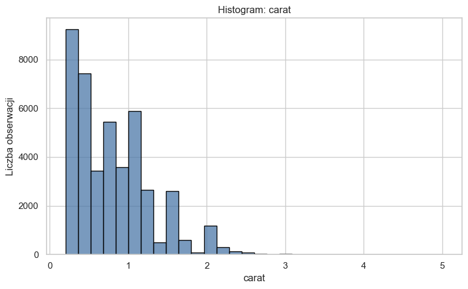

```python
plot_numeric_histogram(diamonds_train_df, CARAT, "Histogram: carat")
```

**opis**: Rozkład zmiennej carat jest silnie prawoskośny – większość diamentów ma niewielką masę (poniżej 1 carata), natomiast duże diamenty występują rzadko. Widoczny jest długi ogon rozkładu w kierunku wyższych wartości oraz obecność obserwacji ekstremalnych. Taka struktura danych sugeruje, że zmienna carat może mieć istotny wpływ na cenę i tłumaczy brak jednoznacznych zależności obserwowanych dla innych cech, takich jak color, clarity czy cut.

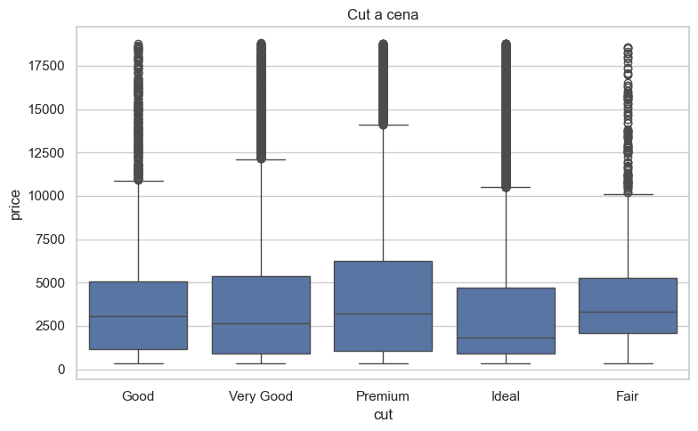

```python
plot_boxplot_vs_price(diamonds_train_df, CUT, "Cut a cena")
```

**opis**: Wykres nie wskazuje na jednoznaczną zależność między jakością szlifu (cut) a ceną diamentu. Mediany cen dla niektórych niższych klas jakości (np. Fair) są wyższe niż dla klas wyższych (np. Ideal), co jest sprzeczne z intuicją. W każdej kategorii obserwujemy również duży rozrzut cen oraz liczne wartości odstające. Sugeruje to, że cut nie jest głównym czynnikiem wpływającym na cenę, a większe znaczenie mają inne zmienne, w szczególności masa diamentu (carat)

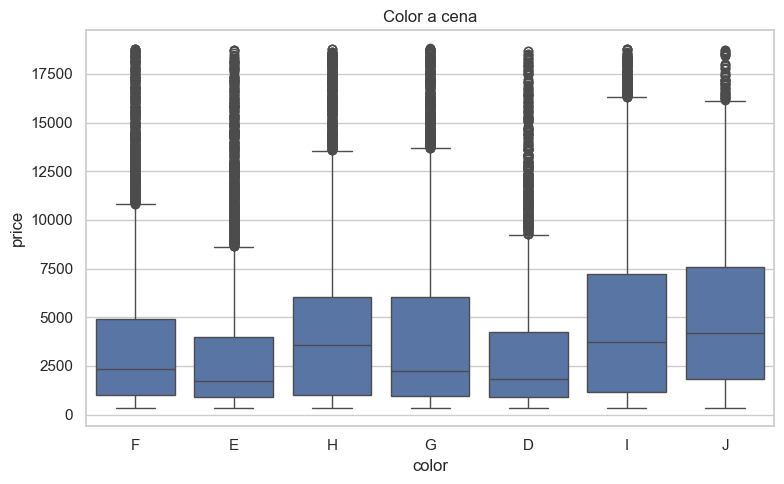

```python
plot_boxplot_vs_price(diamonds_train_df, COLOR, "Color a cena")
```

**opis**: Wykres nie wskazuje na jednoznaczną zależność między kolorem diamentu a jego ceną. Mediany cen dla gorszych klas kolorystycznych (I, J) są wyższe niż dla lepszych (D, E), co jest sprzeczne z intuicją. Dodatkowo ponownie w każdej kategorii obserwujemy duży rozrzut cen oraz liczne wartości odstające. Sugeruje to, że kolor nie jest kluczowym czynnikiem wpływającym na cenę, a większe znaczenie mają inne zmienne, takie jak masa (carat).

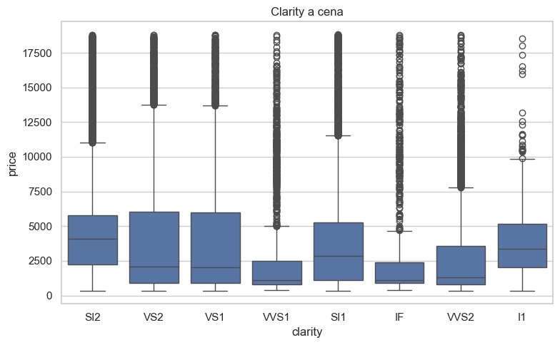

```python
plot_boxplot_vs_price(diamonds_train_df, CLARITY, "Clarity a cena")
```

**opis**: Pomimo że wyższa czystość powinna teoretycznie wiązać się z wyższą ceną, wykres nie pokazuje wyraźnego trendu rosnącego. Mediany cen dla klas IF i VVS1 są niższe niż dla niektórych klas o gorszej czystości (np. SI2), co wskazuje, że inne zmienne mają większy wpływ na cenę.

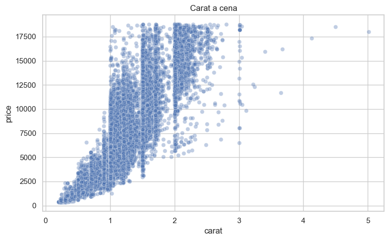

```python
plot_scatter_vs_price(diamonds_train_df, CARAT, "Carat a cena")
```

### Wniosek

Wykresy dla cut, color i clarity pokazują dość nierówne i nieprzewidywalne zależności. Ponieważ carat jest najsilniejszym czynnikiem ceny, to właśnie on wyznacza główny podział modelu.

## Prosty system regresyjny

Zmienna carat została wykorzystana jako główny czynnik predykcyjny, ponieważ w analizie EDA wykazywała najsilniejszą i najbardziej czytelną zależność z ceną diamentu. Na tej podstawie podzielono dane na większą liczbę przedziałów wyznaczonych kwantylowo, a dla każdego koszyka obliczono średnią cenę bazową. Dodatkowo dla najwyższych wartości carat zastosowano gęstszy podział, aby lepiej odwzorować zróżnicowanie cen drogich diamentów.

Pozostałe zmienne jakościowe, czyli cut, color i clarity, nie wykazywały jednoznacznego wpływu na cenę w wykresach, co wynika prawdopodobnie z dominującego znaczenia zmiennej carat. Zostały one jednak wykorzystane jako korekty ceny bazowej. W przypadku diamentów o większej masie ich wpływ został celowo wzmocniony, aby model lepiej oddawał większe rozproszenie cen w górnej części zbioru.

```python
carat_thresholds = [
    diamonds_train_df[CARAT].quantile(0.1),
    diamonds_train_df[CARAT].quantile(0.2),
    diamonds_train_df[CARAT].quantile(0.3),
    diamonds_train_df[CARAT].quantile(0.4),
    diamonds_train_df[CARAT].quantile(0.5),
    diamonds_train_df[CARAT].quantile(0.6),
    diamonds_train_df[CARAT].quantile(0.7),
    diamonds_train_df[CARAT].quantile(0.8),
    diamonds_train_df[CARAT].quantile(0.85),
    diamonds_train_df[CARAT].quantile(0.9),
    diamonds_train_df[CARAT].quantile(0.95),
]

high_carat_threshold = diamonds_train_df[CARAT].quantile(0.8)
very_high_carat_threshold = diamonds_train_df[CARAT].quantile(0.9)


def safe_mean(value: float) -> float:
    if pd.isna(value):
        return float(diamonds_train_df[PRICE].mean())
    return float(value)


bucket_prices = []
lower_bound = float("-inf")

for threshold in carat_thresholds:
    mask = (diamonds_train_df[CARAT] >= lower_bound) & (diamonds_train_df[CARAT] < threshold)
    bucket_price = diamonds_train_df.loc[mask, PRICE].mean()
    bucket_prices.append(safe_mean(bucket_price))
    lower_bound = threshold

last_bucket_price = diamonds_train_df.loc[diamonds_train_df[CARAT] >= lower_bound, PRICE].mean()
bucket_prices.append(safe_mean(last_bucket_price))


def base_price_from_carat(carat: float) -> float:
    for index, threshold in enumerate(carat_thresholds):
        if carat < threshold:
            return float(bucket_prices[index])
    return float(bucket_prices[-1])


def predict_regression(carat, cut, color, clarity, **kwargs) -> float:
    price = base_price_from_carat(carat)

    if color in ["H", "I", "J"]:
        price = price * 0.98
    if color in ["D", "E", "F"]:
        price = price * 1.02

    if cut in ["Ideal", "Premium"]:
        price = price * 1.03
    if cut in ["Fair", "Good"]:
        price = price * 0.97

    if clarity in ["IF", "VVS1", "VVS2"]:
        price = price * 1.03
    if clarity in ["SI2", "I1"]:
        price = price * 0.97

    if carat >= high_carat_threshold:
        if color in ["D", "E", "F"]:
            price = price * 1.05
        if color in ["H", "I", "J"]:
            price = price * 0.95
        if cut in ["Ideal", "Premium"]:
            price = price * 1.06
        if cut in ["Fair", "Good"]:
            price = price * 0.93
        if clarity in ["IF", "VVS1", "VVS2"]:
            price = price * 1.06
        if clarity in ["SI2", "I1"]:
            price = price * 0.92

    if carat >= very_high_carat_threshold:
        if cut in ["Ideal", "Premium"] and color in ["D", "E", "F"]:
            price = price * 1.08
        if clarity in ["IF", "VVS1", "VVS2"]:
            price = price * 1.05

    return float(price)
```

```python
train_predictions_reg = diamonds_train_df.apply(
    lambda row: predict_regression(
        row[CARAT],
        row[CUT],
        row[COLOR],
        row[CLARITY],
    ),
    axis=1,
)

test_predictions_reg = diamonds_test_df.apply(
    lambda row: predict_regression(
        row[CARAT],
        row[CUT],
        row[COLOR],
        row[CLARITY],
    ),
    axis=1,
)

mse_train = mean_squared_error(diamonds_train_df[PRICE], train_predictions_reg)
mae_train = mean_absolute_error(diamonds_train_df[PRICE], train_predictions_reg)
mse_test = mean_squared_error(diamonds_test_df[PRICE], test_predictions_reg)
mae_test = mean_absolute_error(diamonds_test_df[PRICE], test_predictions_reg)

print(f"Train MSE: {mse_train:.2f}")
print(f"Train MAE: {mae_train:.2f}")
print(f"Test MSE: {mse_test:.2f}")
print(f"Test MAE: {mae_test:.2f}")
```

```
Train MSE: 1760021.29
Train MAE: 779.73
Test MSE: 1732998.22
Test MAE: 776.56
```

### interpretacja

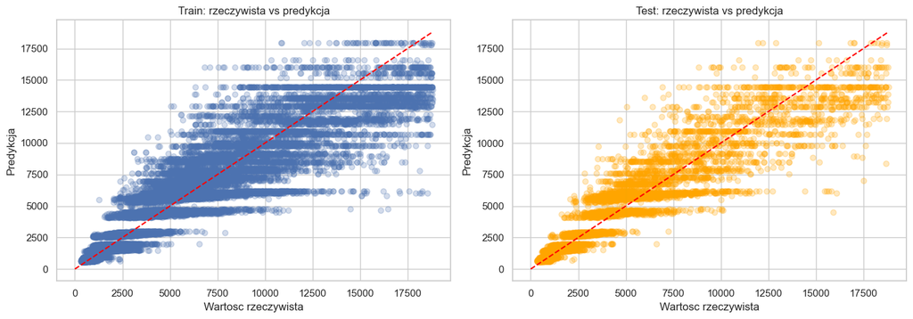

```python
fig, axes = plt.subplots(1, 2, figsize=(14, 5))

axes[0].scatter(diamonds_train_df[PRICE], train_predictions_reg, alpha=0.25)
axes[0].plot([0, diamonds_train_df[PRICE].max()], [0, diamonds_train_df[PRICE].max()], color="red", linestyle="--")
axes[0].set_title("Train: rzeczywista vs predykcja")
axes[0].set_xlabel("Wartosc rzeczywista")
axes[0].set_ylabel("Predykcja")

axes[1].scatter(diamonds_test_df[PRICE], test_predictions_reg, alpha=0.25, color="orange")
axes[1].plot([0, diamonds_test_df[PRICE].max()], [0, diamonds_test_df[PRICE].max()], color="red", linestyle="--")
axes[1].set_title("Test: rzeczywista vs predykcja")
axes[1].set_xlabel("Wartosc rzeczywista")
axes[1].set_ylabel("Predykcja")

plt.tight_layout()
plt.show()
```

# Interpretacja

Widoczne na wykresach poziome pasy predykcji wynikają z zastosowanego podziału zmiennej carat na przedziały, dla których przypisywane są średnie wartości ceny. Powoduje to, że model nie wyznacza ceny w sposób w pełni ciągły, lecz operuje na dyskretnych poziomach predykcji.

Jednocześnie można zauważyć, że model stosunkowo dobrze odwzorowuje ogólną zależność między masą diamentu a jego ceną, ponieważ większość punktów układa się wzdłuż rosnącego trendu.

W dalszym ciągu widoczna jest jednak tendencja do niedoszacowywania najwyższych cen — dla dużych wartości rzeczywistych część punktów znajduje się powyżej linii predykcji, co wskazuje na ograniczoną zdolność modelu do uchwycenia najbardziej ekstremalnych przypadków.

# Wnioski końcowe

Ręczne projektowanie reguł było wykonalne tylko dlatego, że liczba cech była ograniczona i dało się wizualnie wskazać kilka najważniejszych zależności. Przy zbiorze zawierającym np. 1000 cech pojawiłby się problem dużej liczby możliwych kombinacji warunków, trudności w doborze progów, niskiej interpretowalności oraz bardzo dużego ryzyka przeuczenia. To właśnie dlatego w praktyce stosuje się klasyczne modele ML, które potrafią automatycznie wybierać istotne zależności i lepiej generalizować na nowe dane.